# Project: No-show appoinments

- Introduction
- Data Wrangling
- Exploratory Data Analysis
- Conclusions

## Introduction

In this project we will investigate a dataset that gatheres information from 100k medical appointments in Brazil. The dataset contains information about each appointment such as: gender, age, date of scheduling, date of actual appointment, neighborhood, wheather the pateints are holding scholarship or not , sms-reminder as well as wheather the pateint suffer from one or more disease. our analysis will focus on the different factors that may affect the show-up of pateints to their appointment.

Questions to explore during this project:2

1. Do factors such as receiving SMS, Age, Gender, Scholarship affect pateints showing up to their appointments?
2. what is the show up ratio and the time span between scheduling the appointment and the appointment day and how the showing up percentage is affected by the waiting days?
3. Which Neighbourhoods are associated with the highst no. of show up pateints?
4. Does the pateint suffering from a disease affect his/her showing up?

```python
import pandas as pd
import numpy as np
import matplotlib.pyplot as plt
import seaborn as sns
%matplotlib inline
```

## Data Wrangling

```python
# Load your data and print out a few lines to inspect data
df= pd.read_csv ('noshowappointments-kagglev2-may-2016.csv')
df.head()
```

|  | PatientId | AppointmentID | Gender | ScheduledDay | AppointmentDay | Age | Neighbourhood | Scholarship | Hipertension | Diabetes | Alcoholism | Handcap | SMS_received | No-show |
| --- | --- | --- | --- | --- | --- | --- | --- | --- | --- | --- | --- | --- | --- | --- |
| 0 | 2.987250e+13 | 5642903 | F | 2016-04-29T18:38:08Z | 2016-04-29T00:00:00Z | 62 | JARDIM DA PENHA | 0 | 1 | 0 | 0 | 0 | 0 | No |
| 1 | 5.589978e+14 | 5642503 | M | 2016-04-29T16:08:27Z | 2016-04-29T00:00:00Z | 56 | JARDIM DA PENHA | 0 | 0 | 0 | 0 | 0 | 0 | No |
| 2 | 4.262962e+12 | 5642549 | F | 2016-04-29T16:19:04Z | 2016-04-29T00:00:00Z | 62 | MATA DA PRAIA | 0 | 0 | 0 | 0 | 0 | 0 | No |
| 3 | 8.679512e+11 | 5642828 | F | 2016-04-29T17:29:31Z | 2016-04-29T00:00:00Z | 8 | PONTAL DE CAMBURI | 0 | 0 | 0 | 0 | 0 | 0 | No |
| 4 | 8.841186e+12 | 5642494 | F | 2016-04-29T16:07:23Z | 2016-04-29T00:00:00Z | 56 | JARDIM DA PENHA | 0 | 1 | 1 | 0 | 0 | 0 | No |

```python
# to determine the columns and rows number
df.shape
```

```
(110527, 14)
```

```python
# to get breif describtion and some statistical analysis for our data
df.describe()
```

|  | PatientId | AppointmentID | Age | Scholarship | Hipertension | Diabetes | Alcoholism | Handcap | SMS_received |
| --- | --- | --- | --- | --- | --- | --- | --- | --- | --- |
| count | 1.105270e+05 | 1.105270e+05 | 110527.000000 | 110527.000000 | 110527.000000 | 110527.000000 | 110527.000000 | 110527.000000 | 110527.000000 |
| mean | 1.474963e+14 | 5.675305e+06 | 37.088874 | 0.098266 | 0.197246 | 0.071865 | 0.030400 | 0.022248 | 0.321026 |
| std | 2.560949e+14 | 7.129575e+04 | 23.110205 | 0.297675 | 0.397921 | 0.258265 | 0.171686 | 0.161543 | 0.466873 |
| min | 3.921784e+04 | 5.030230e+06 | -1.000000 | 0.000000 | 0.000000 | 0.000000 | 0.000000 | 0.000000 | 0.000000 |
| 25% | 4.172614e+12 | 5.640286e+06 | 18.000000 | 0.000000 | 0.000000 | 0.000000 | 0.000000 | 0.000000 | 0.000000 |
| 50% | 3.173184e+13 | 5.680573e+06 | 37.000000 | 0.000000 | 0.000000 | 0.000000 | 0.000000 | 0.000000 | 0.000000 |
| 75% | 9.439172e+13 | 5.725524e+06 | 55.000000 | 0.000000 | 0.000000 | 0.000000 | 0.000000 | 0.000000 | 1.000000 |
| max | 9.999816e+14 | 5.790484e+06 | 115.000000 | 1.000000 | 1.000000 | 1.000000 | 1.000000 | 4.000000 | 1.000000 |

```python
# to get more information about data type, column names, no. of intry, null values.
df.info()
```

```
<class 'pandas.core.frame.DataFrame'>
RangeIndex: 110527 entries, 0 to 110526
Data columns (total 14 columns):
 #   Column          Non-Null Count   Dtype
---  ------          --------------   -----
 0   PatientId       110527 non-null  float64
 1   AppointmentID   110527 non-null  int64
 2   Gender          110527 non-null  object
 3   ScheduledDay    110527 non-null  object
 4   AppointmentDay  110527 non-null  object
 5   Age             110527 non-null  int64
 6   Neighbourhood   110527 non-null  object
 7   Scholarship     110527 non-null  int64
 8   Hipertension    110527 non-null  int64
 9   Diabetes        110527 non-null  int64
 10  Alcoholism      110527 non-null  int64
 11  Handcap         110527 non-null  int64
 12  SMS_received    110527 non-null  int64
 13  No-show         110527 non-null  object
dtypes: float64(1), int64(8), object(5)
memory usage: 11.8+ MB
```

```python
# to check for duplication and ensuring that no null values are present in our dataset.
df.duplicated().sum(), df.isnull().sum().sum()
```

```
(0, 0)
```

### Data Cleaning

we will clean our data as following:

1. changing datatype of some columns to appropriate datatype so that we can easily extract date and analyze it.
2. change the column name and correct the typos to more readable way and better in column calling
3. correcting the wrong age values (age<0)

```python
# changing datatype of some columns to a datetime datatype so that we can easily extract date and analyse the data
df['ScheduledDay'] = pd.to_datetime(df['ScheduledDay'])
df['AppointmentDay'] = pd.to_datetime(df['AppointmentDay'])
df. info()
```

```
<class 'pandas.core.frame.DataFrame'>
RangeIndex: 110527 entries, 0 to 110526
Data columns (total 14 columns):
 #   Column          Non-Null Count   Dtype
---  ------          --------------   -----
 0   PatientId       110527 non-null  float64
 1   AppointmentID   110527 non-null  int64
 2   Gender          110527 non-null  object
 3   ScheduledDay    110527 non-null  datetime64[ns, UTC]
 4   AppointmentDay  110527 non-null  datetime64[ns, UTC]
 5   Age             110527 non-null  int64
 6   Neighbourhood   110527 non-null  object
 7   Scholarship     110527 non-null  int64
 8   Hipertension    110527 non-null  int64
 9   Diabetes        110527 non-null  int64
 10  Alcoholism      110527 non-null  int64
 11  Handcap         110527 non-null  int64
 12  SMS_received    110527 non-null  int64
 13  No-show         110527 non-null  object
dtypes: datetime64[ns, UTC](2), float64(1), int64(8), object(3)
memory usage: 11.8+ MB
```

```python
# make all column names in lower case letters for easy read and call
df.rename(columns= lambda x: x.lower(), inplace=True)
```

```python
# rename the columns and correct typo mistakes
df.rename(columns={'no-show': 'no_show', 'hipertension': 'hypertension', 'handcap': 'handicap'}, inplace=True)
df.head(1)
```

|  | patientid | appointmentid | gender | scheduledday | appointmentday | age | neighbourhood | scholarship | hypertension | diabetes | alcoholism | handicap | sms_received | no_show |
| --- | --- | --- | --- | --- | --- | --- | --- | --- | --- | --- | --- | --- | --- | --- |
| 0 | 2.987250e+13 | 5642903 | F | 2016-04-29 18:38:08+00:00 | 2016-04-29 00:00:00+00:00 | 62 | JARDIM DA PENHA | 0 | 1 | 0 | 0 | 0 | 0 | No |

```python
# correct the age values less than 0 and replace it with the mean value of age column
df.loc[df['age'] < 0, 'age'] = int(df['age'].mean())
df.describe()
```

|  | patientid | appointmentid | age | scholarship | hypertension | diabetes | alcoholism | handicap | sms_received |
| --- | --- | --- | --- | --- | --- | --- | --- | --- | --- |
| count | 1.105270e+05 | 1.105270e+05 | 110527.000000 | 110527.000000 | 110527.000000 | 110527.000000 | 110527.000000 | 110527.000000 | 110527.000000 |
| mean | 1.474963e+14 | 5.675305e+06 | 37.089218 | 0.098266 | 0.197246 | 0.071865 | 0.030400 | 0.022248 | 0.321026 |
| std | 2.560949e+14 | 7.129575e+04 | 23.109921 | 0.297675 | 0.397921 | 0.258265 | 0.171686 | 0.161543 | 0.466873 |
| min | 3.921784e+04 | 5.030230e+06 | 0.000000 | 0.000000 | 0.000000 | 0.000000 | 0.000000 | 0.000000 | 0.000000 |
| 25% | 4.172614e+12 | 5.640286e+06 | 18.000000 | 0.000000 | 0.000000 | 0.000000 | 0.000000 | 0.000000 | 0.000000 |
| 50% | 3.173184e+13 | 5.680573e+06 | 37.000000 | 0.000000 | 0.000000 | 0.000000 | 0.000000 | 0.000000 | 0.000000 |
| 75% | 9.439172e+13 | 5.725524e+06 | 55.000000 | 0.000000 | 0.000000 | 0.000000 | 0.000000 | 0.000000 | 1.000000 |
| max | 9.999816e+14 | 5.790484e+06 | 115.000000 | 1.000000 | 1.000000 | 1.000000 | 1.000000 | 4.000000 | 1.000000 |

```python
# creating new data frames for the pateints who showed up or missed their appointment
df['showed']= df['no_show']=="No"
df['notshowed']=df['no_show']=="Yes"
df.head(1)
```

|  | patientid | appointmentid | gender | scheduledday | appointmentday | age | neighbourhood | scholarship | hypertension | diabetes | alcoholism | handicap | sms_received | no_show | showed | notshowed |
| --- | --- | --- | --- | --- | --- | --- | --- | --- | --- | --- | --- | --- | --- | --- | --- | --- |
| 0 | 2.987250e+13 | 5642903 | F | 2016-04-29 18:38:08+00:00 | 2016-04-29 00:00:00+00:00 | 62 | JARDIM DA PENHA | 0 | 1 | 0 | 0 | 0 | 0 | No | True | False |

## Exploratory Data Analysis

### Research Question 1:

#### Do factors such as receiving SMS, Age, Gender, Scholarship affect pateints showing up to their appointments?

#### part1: Receiving SMS Factor

```python
#generating a function for chart labelling of x and y axis and stating the title
def chart_label(x_label,y_label,Title):
    plt.xlabel(x_label,  fontsize='xx-large')
    plt.ylabel(y_label, fontsize='xx-large')
    plt.title(Title, fontsize='xx-large');
    return plt.show()
```

```python
# counting no. of pateints who received sms and who did not
df['sms_received'].value_counts()
```

```
0    75045
1    35482
Name: sms_received, dtype: int64
```

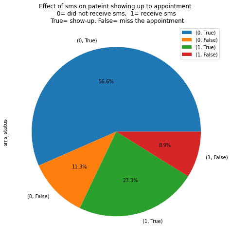

```python
# ploting and comparing the no. of pateint who received/didn't receive sms and went/didn't go to their appointment
plot= df.groupby('sms_received')['showed'].value_counts().plot(kind='pie', autopct='%1.1f%%', figsize=(8,8), ylabel='sms_status', legend= True)
plt.title('Effect of sms on pateint showing up to appointment \n 0= did not receive sms,  1= receive sms \n True= show-up, False= miss the appointment');
```

### Research Question 2:

#### Do factors such as receiving SMS, Age, Gender, Scholarship affect pateints showing up to their appointments?

#### part2: Age Factor

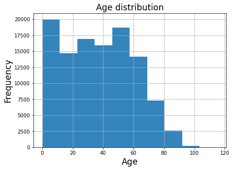

```python
# ploting the age of pateints to explore the age distribution
df["age"].hist(alpha= 0.9,figsize=(7,5), bins =10)
chart_label('Age', 'Frequency', 'Age distribution')
```

```python
# determine the mean of age for the pateint who showed up and those who did not
df.groupby('showed')['age'].mean()
```

```
showed
False    34.317667
True     37.790495
Name: age, dtype: float64
```

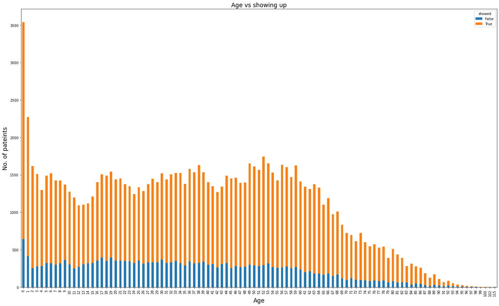

```python
# ploting stacked the age of pateints to investigate the relationship of age and showing up percentage
df.groupby('age')['showed'].value_counts().unstack().plot(kind='bar',  stacked=True, figsize=(25,15))
chart_label('Age', 'No. of pateints', 'Age vs showing up')
```

age may be a relative factor for pateint showing up to their appointment as mean age of pateint who show up was 37.79049620073249 while who did not was 34.31766656212196

### Research Question 3:

#### Do factors such as receiving SMS, Age, Gender, Scholarship affect pateints showing up to their appointments?

#### part3: Gender Factor

```python
# counting the no. of female vs male pateint
total = df['gender'].value_counts()
print(total)
```

```
F    71840
M    38687
Name: gender, dtype: int64
```

```python
# counting the no. of female vs male pateint who show up
g_showed = df.groupby('gender')['showed'].value_counts()
print(g_showed)
```

```
gender  showed
F       True      57246
        False     14594
M       True      30962
        False      7725
Name: showed, dtype: int64
```

```python
#calculating the percentage of female vs male pateint who show up
female_appearance= g_showed[0]/total[0] *100
male_appearance= g_showed[2]/total[1] *100
print('female pateints appearance percentage= {}, male pateints appearance percentage= {}'.format(female_appearance, male_appearance) )
```

```
female pateints appearance percentage= 79.68541202672606, male pateints appearance percentage= 80.03205211052808
```

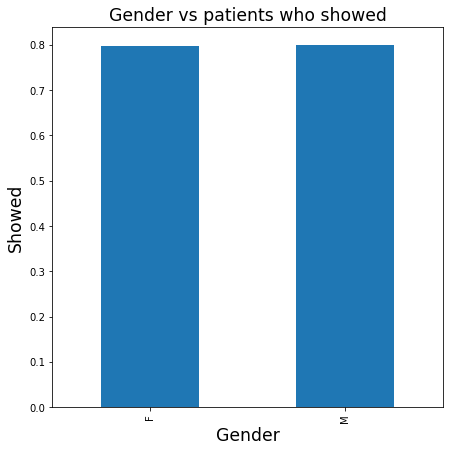

```python
#plotting the percentage of female vs male pateint who show up
df.groupby('gender')['showed'].mean().plot(kind='bar',figsize=(7,7));
chart_label("Gender","Showed","Gender vs patients who showed");
```

no attribute of pateint gender on showing up to appointmnents as almost equal percentage were detected

### Research Question 4:

#### Do factors such as receiving SMS, Age, Gender, Scholarship affect pateints showing up to their appointments?

#### part4: Scholarship Factor

[figure not shown]

```python
#counting the no.of pateints who showed up with and without scholarship and plotting it
df.groupby('scholarship')['showed'].value_counts().plot(kind='bar', figsize=(10,6))
plt.xticks(ticks=[0,1,2,3], labels=['no-scholarship & showed','no-scholarship & not-showed', 'scholarship & showed ','no-scholarship & not-showed'], rotation=40)
chart_label('scholarship', 'no.of pateints', 'Scholarship vs no-Scholarship pateints')
```

### Research Question 5:

#### what is the show up ratio and the time span between scheduling the appointment and the appointment day and how the showing up percentage is affected by the waiting days?

#### part1: show up rate

```python
#calculating the rate of showing up pateints
df.query('showed ==True').value_counts().sum() / df['showed'].count() *100
```

```
79.8067440534892
```

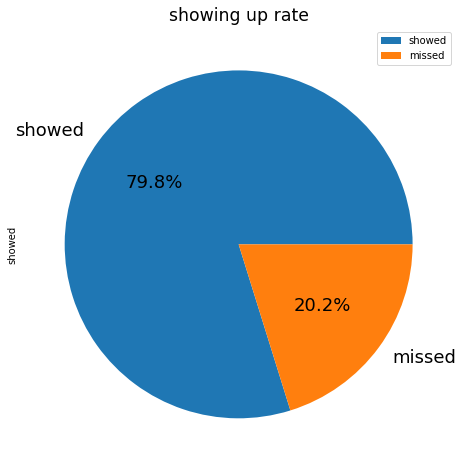

```python
#plotting the rate of showing up pateints
df['showed'].value_counts().plot(kind='pie', figsize=(8,8), autopct='%1.1f%%', fontsize=18, legend=True, labels=['showed','missed'])
plt.title('showing up rate', fontsize='xx-large');
```

20.2 % of pateints who schedueled an appointment didnot show up for their appointment.

### Research Question 6:

#### what is the show up ratio and the time span between scheduling the appointment and the appointment day and how the showing up percentage is affected by the waiting days?

#### part2: Time span

```python
#calculating time span by substracting the date of the appointment from the scheduled day
df['time_span']= df['appointmentday'].dt.date- df['scheduledday'].dt.date
df.head()
```

|  | patientid | appointmentid | gender | scheduledday | appointmentday | age | neighbourhood | scholarship | hypertension | diabetes | alcoholism | handicap | sms_received | no_show | showed | notshowed | time_span |
| --- | --- | --- | --- | --- | --- | --- | --- | --- | --- | --- | --- | --- | --- | --- | --- | --- | --- |
| 0 | 2.987250e+13 | 5642903 | F | 2016-04-29 18:38:08+00:00 | 2016-04-29 00:00:00+00:00 | 62 | JARDIM DA PENHA | 0 | 1 | 0 | 0 | 0 | 0 | No | True | False | 0 days |
| 1 | 5.589978e+14 | 5642503 | M | 2016-04-29 16:08:27+00:00 | 2016-04-29 00:00:00+00:00 | 56 | JARDIM DA PENHA | 0 | 0 | 0 | 0 | 0 | 0 | No | True | False | 0 days |
| 2 | 4.262962e+12 | 5642549 | F | 2016-04-29 16:19:04+00:00 | 2016-04-29 00:00:00+00:00 | 62 | MATA DA PRAIA | 0 | 0 | 0 | 0 | 0 | 0 | No | True | False | 0 days |
| 3 | 8.679512e+11 | 5642828 | F | 2016-04-29 17:29:31+00:00 | 2016-04-29 00:00:00+00:00 | 8 | PONTAL DE CAMBURI | 0 | 0 | 0 | 0 | 0 | 0 | No | True | False | 0 days |
| 4 | 8.841186e+12 | 5642494 | F | 2016-04-29 16:07:23+00:00 | 2016-04-29 00:00:00+00:00 | 56 | JARDIM DA PENHA | 0 | 1 | 1 | 0 | 0 | 0 | No | True | False | 0 days |

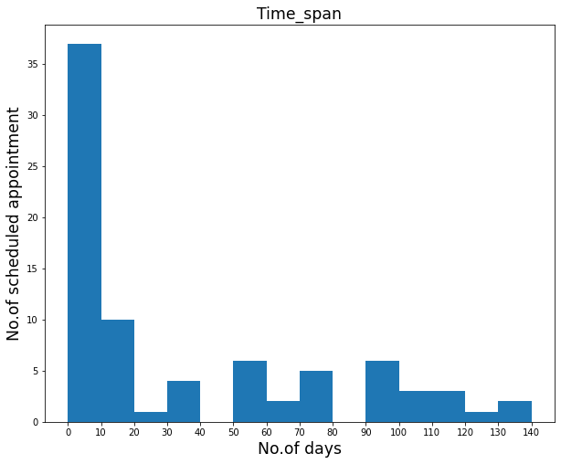

```
The general range between scheduling an appointment and actual appointment:
 0 days      38563
2 days       6725
4 days       5290
1 days       5213
7 days       4906
            ...
82 days         1
127 days        1
126 days        1
151 days        1
123 days        1
Name: time_span, Length: 131, dtype: int64
```

```python
#counting no. of waiting days vs no.of pateints who scheduled the appointment
# plotting a histogram to determine the most common no. days between scheduling the and the appointment actual date
bins= [0,10,20,30,40,50,60,70,80,90,100,110,120,130, 140]
df['time_span'].value_counts().plot(kind='hist',bins=bins, figsize=(10,8))
plt.xticks(bins)
chart_label('No.of days', 'No.of scheduled appointment', 'Time_span')
print('The general range between scheduling an appointment and actual appointment: \n {}'.format(df['time_span'].value_counts()))
```

it seems that the majority of pateints schedule their appointment in the same day or within 10 days.

### Research Question 7:

#### what is the show up ratio and the time span between scheduling the appointment and the appointment day and how the showing up percentage is affected by the waiting days?

#### part3: how the showing up percentage is affected by the waiting days?

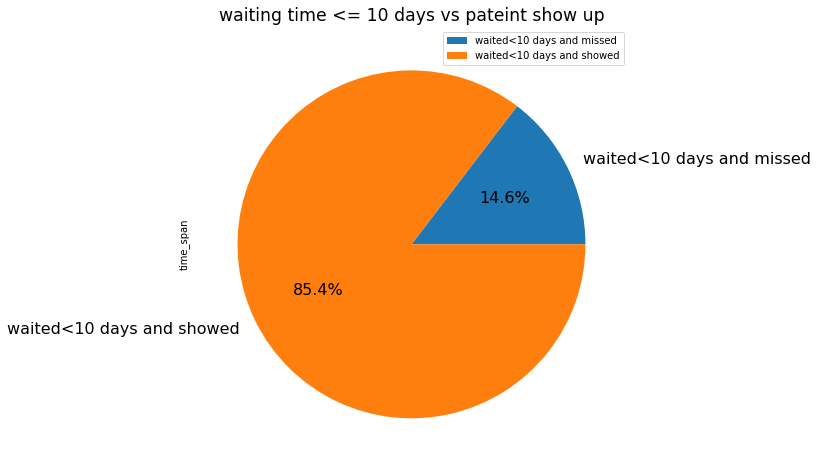

```python
# converting the dtype of time_span column from date time to int
# filter out no. of pateint with less than 10 waiting days
# detrmining the relationship between the waiting time and pateint show up (a: <= 10 days)
waiting_time= df.loc[df['time_span'] <='10 days']
waiting_time.groupby('showed')['time_span'].count().plot(kind='pie', figsize=(8,8), autopct='%1.1f%%', fontsize=16, legend=True, labels=['waited<10 days and missed','waited<10 days and showed'])
plt.title('waiting time <= 10 days vs pateint show up', fontsize='xx-large');
```

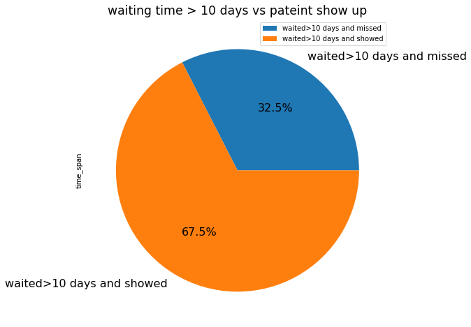

```python
# detrmining the relationship between the waiting time and pateint show up (a: > 10 days)
waiting_time= df.loc[df['time_span'] >'10 days']
waiting_time.groupby('showed')['time_span'].count().plot(kind='pie', figsize=(8,8), autopct='%1.1f%%', fontsize=16, legend=True, labels=['waited>10 days and missed','waited>10 days and showed'])
plt.title('waiting time > 10 days vs pateint show up', fontsize='xx-large');
```

the pateint show up pecentage when the waiting days for the appointment actual date is less than or equal to 10 days was 85.4% and dropped to 67.5% when the waiting days for the appointment actual date is more than 10 days

### Research Question 8:

#### Which Neighbourhoods are associated with the highst no. of show up pateints?

```python
# determining how many neighbourhoods are there and counting no. of each one (most frequent)
df['neighbourhood'].value_counts()
```

```
JARDIM CAMBURI                 7717
MARIA ORTIZ                    5805
RESISTÊNCIA                    4431
JARDIM DA PENHA                3877
ITARARÉ                        3514
                               ...
ILHA DO BOI                      35
ILHA DO FRADE                    10
AEROPORTO                         8
ILHAS OCEÂNICAS DE TRINDADE       2
PARQUE INDUSTRIAL                 1
Name: neighbourhood, Length: 81, dtype: int64
```

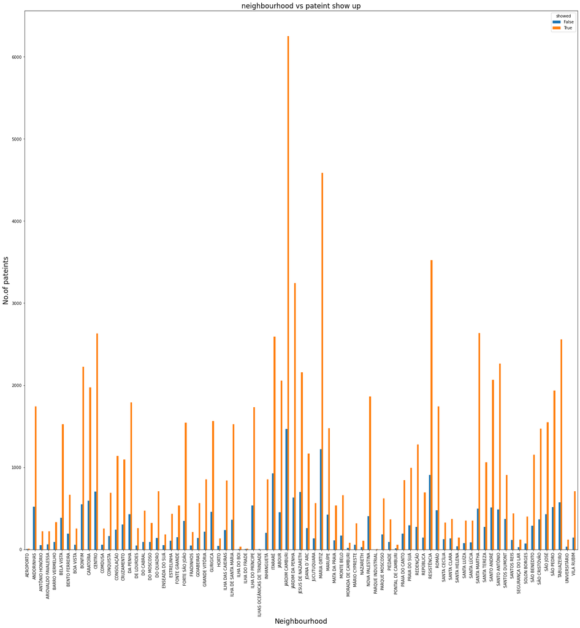

```python
#plotting each neighbourhood against no.of showed up and missed pateints
df.groupby('neighbourhood')['showed'].value_counts().unstack().plot(kind = "bar", figsize = (25,25))
chart_label('Neighbourhood', 'No.of pateints', 'neighbourhood vs pateint show up')
```

```python
# checking the one neighbourhood with no showing up pateints determined from the graph
df.query('neighbourhood=="ILHAS OCEÂNICAS DE TRINDADE"')
```

|  | patientid | appointmentid | gender | scheduledday | appointmentday | age | neighbourhood | scholarship | hypertension | diabetes | alcoholism | handicap | sms_received | no_show | showed | notshowed | time_span |
| --- | --- | --- | --- | --- | --- | --- | --- | --- | --- | --- | --- | --- | --- | --- | --- | --- | --- |
| 48754 | 5.349869e+11 | 5583947 | F | 2016-04-14 12:25:43+00:00 | 2016-05-13 00:00:00+00:00 | 51 | ILHAS OCEÂNICAS DE TRINDADE | 0 | 0 | 0 | 0 | 0 | 0 | Yes | False | True | 29 days |
| 48765 | 7.256430e+12 | 5583948 | F | 2016-04-14 12:26:13+00:00 | 2016-05-13 00:00:00+00:00 | 58 | ILHAS OCEÂNICAS DE TRINDADE | 0 | 0 | 0 | 0 | 0 | 0 | Yes | False | True | 29 days |

```python
# determining the top 5 neighbourhood for pateint showing up
showing = df.query('showed == True')
showing_per_neighb = showing.groupby("neighbourhood")["showed"].count().reset_index(name="count").sort_values("count", ascending=False)
showing_per_neighb.head()
```

|  | neighbourhood | count |
| --- | --- | --- |
| 37 | JARDIM CAMBURI | 6252 |
| 42 | MARIA ORTIZ | 4586 |
| 58 | RESISTÊNCIA | 3525 |
| 38 | JARDIM DA PENHA | 3246 |
| 65 | SANTA MARTHA | 2635 |

### Research Question 9:

#### Does the pateint suffering from a disease affect his/her showing up?

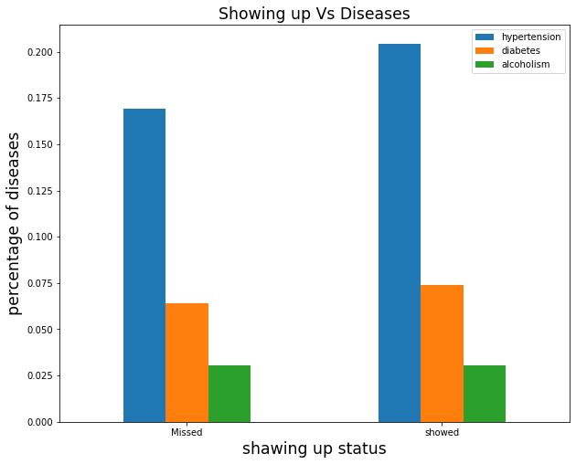

```python
#determining the mean of each disease regarding showing up pateints vs missed pateints
#plotting bar chart for visualizing
df.groupby('showed').mean()[['hypertension','diabetes','alcoholism']].plot(kind='bar', figsize=(10,8))
plt.xticks(ticks=[0,1], labels=['Missed','showed'], rotation=0)
chart_label('shawing up status', 'percentage of diseases', 'Showing up Vs Diseases')
```

it seems that the pateint suffering from a certein disease either hypertension, diabetes or alcoholism doesn't greatly affect the pateint showing up as it provide comparible percentages for diabetes and alcoholism and slight difference for hypertension (showing up=~20%, not showed=~17.5%) .

## Conclusions

### Limitations

1. The collected dataset investigated in this analysis was over a short period time and require more clarification regarding geografical data, weather condition so that the Data would provide more insight into other factors affecting the show up rates.
2. More data collection and analysis are required for the health status regarding each pateint and how it could affect his/her showing up to appointment.